# Penguins_Zoe

Zoe Zilz

11/7/2018

1. Load packages and read in penguins.csv

```r
library(tidyverse)
library(car)
library(onewaytests)

penguins <- read.csv("penguins.csv")
```

### Our question is: Is there a significant difference in mean flipper lengths for female chinstrap, gentoo, and adelie penguins near Palmer Archipelago

How many factors do I have? 1 - Species 3 levels - chinstrap, gentoo, adelie 1 continuous random variable - flipper length

More than 2 groups for continuous measured data – maybe I can use a one way ANOVA? assume: independent observations - sure assume: equal variance - will use Levene’s test for assume: normality - use histograms and qq plots to explore this

First, want to know how many observations are in each group (why?) can use table function to calculate counts based on however many factors you give it

```r
counts <- with(penguins, table(species,sex))

#updating dataset because Allison doesn't like penguin names
# using case when to add a column called "common name"

penguins2 <- penguins %>%
  mutate(
    common_name =
      case_when(
        species == "Chinstrap penguin (Pygoscelis antarctica)" ~ "chinstrap",
        species == "Adelie Penguin (Pygoscelis adeliae)" ~ "adelie",
        species == "Gentoo penguin (Pygoscelis papua)" ~ "gentoo"
      )
  ) %>%
  select(-species) %>%
  filter(sex =="FEMALE")
```

Exploratory graphs and Levene’s test for equal variances

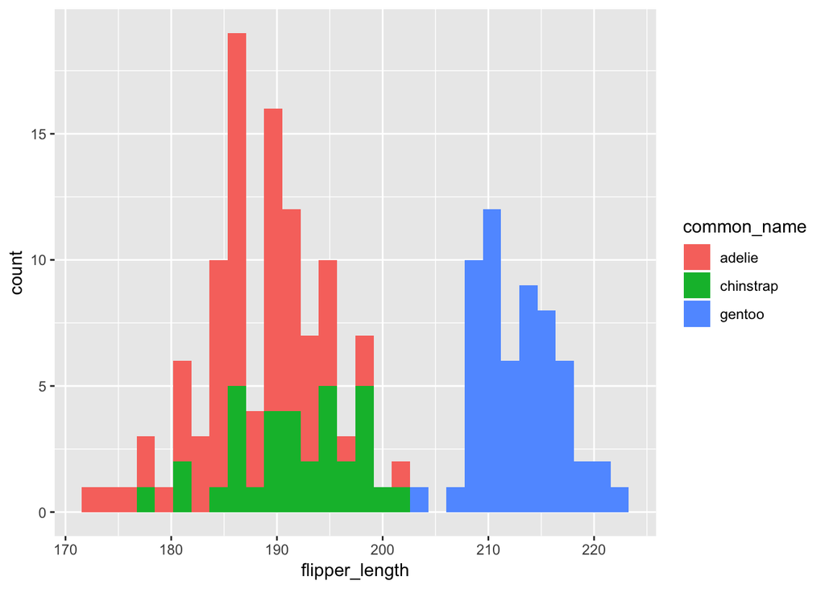

```r
# maybe grouped differently?
hist1 <- ggplot(penguins2, aes( x = flipper_length))+
  geom_histogram(aes(fill = common_name))

hist1
```

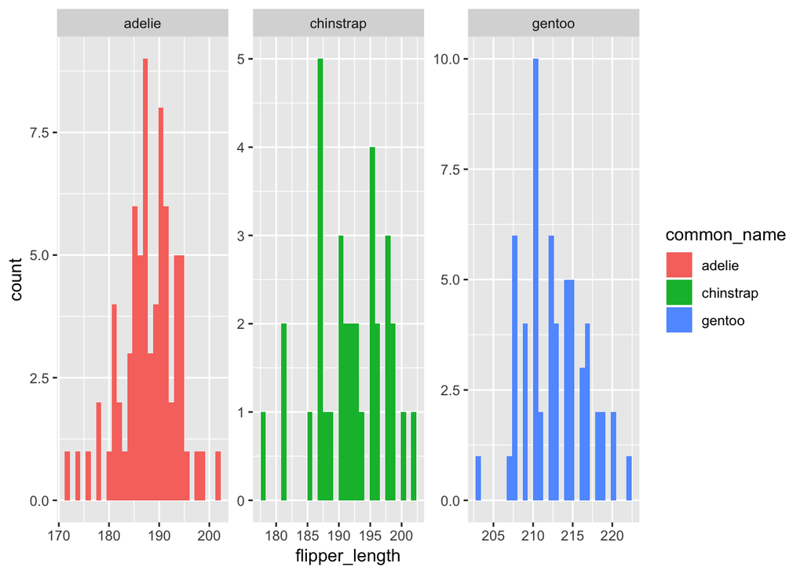

```r
#yeah!

#normally distributed?
hist2 <- ggplot(penguins2, aes( x = flipper_length))+
  geom_histogram(aes(fill = common_name))+
  facet_wrap(~common_name, scale = "free")

hist2
```

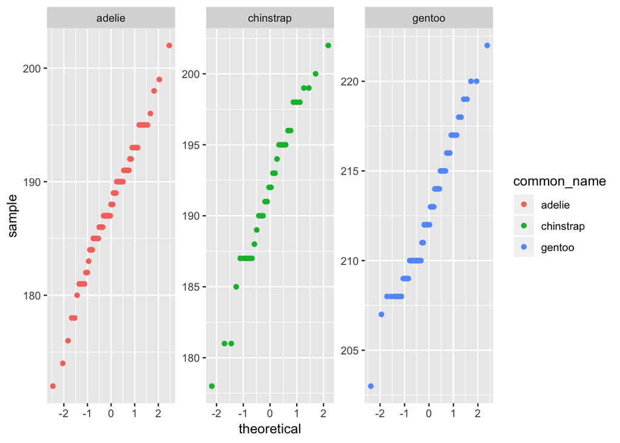

```r
#looks pretty norm

qqs <- ggplot(penguins2, aes(sample = flipper_length)) +
  geom_qq(aes(color = common_name)) +
  facet_wrap(~common_name, scale = "free")

qqs
```

```r
#based on qq plots and hists, obs for each group appear normall distributed. also n > 30 for all groups, so means will be normally distributed by CLT
```

Evaluate variance and perform a Levene’s Test for equal variances

If the largest sample variance is < 4x greater than the smallest sample variance, then these are “close enough” to consider variances equal

```r
#using group_by
variances <- penguins2 %>%
  group_by(common_name) %>%
  summarize(
    variance = var(flipper_length)
  )

variances # the largest variance is definitely not more than 4x the smallest variance
```

```
## # A tibble: 3 x 2
##   common_name variance
##   <chr>          <dbl>
## 1 adelie          31.3
## 2 chinstrap       33.1
## 3 gentoo          15.2
```

```r
# Levene's Test
# leveneTest function in 'car'

levene_penguin <- leveneTest(flipper_length ~ common_name, data = penguins2)
levene_penguin
```

```
## Levene's Test for Homogeneity of Variance (center = median)
##        Df F value  Pr(>F)
## group   2  2.9012 0.05782 .
##       162
## ---
## Signif. codes:  0 '***' 0.001 '**' 0.01 '*' 0.05 '.' 0.1 ' ' 1
```

```r
# H0: no difference in variances (equal)
# HA: Variances are NOT equal

# Here, there is not significant differnece in variances across species p > 0.05
```

One-Way ANOVA for penguin flipper lengths by species (common_name)

```r
# ASKING R: please compare means based on the rand variable flipper_length as a function of common_name, and you're going to get that from penguins2

penguin_aov <- aov(flipper_length ~ common_name, data = penguins2)
summary(penguin_aov)
```

```
##              Df Sum Sq Mean Sq F value Pr(>F)
## common_name   2  21416   10708   411.8 <2e-16 ***
## Residuals   162   4213      26
## ---
## Signif. codes:  0 '***' 0.001 '**' 0.01 '*' 0.05 '.' 0.1 ' ' 1
```

```r
# then full report using summary to get anova outcome

# H0: Means across all groups are equal
# HA: At least two group means differ significantly

#follow up, post hoc, which differ?

#Tukey's HSD (works nicely with aov() function )

penguin_ph <- TukeyHSD(penguin_aov)
penguin_ph
```

```
##   Tukey multiple comparisons of means
##     95% family-wise confidence level
##
## Fit: aov(formula = flipper_length ~ common_name, data = penguins2)
##
## $common_name
##                       diff       lwr       upr     p adj
## chinstrap-adelie  3.940774  1.436275  6.445272 0.0007922
## gentoo-adelie    24.912376 22.790647 27.034105 0.0000000
## gentoo-chinstrap 20.971602 18.366227 23.576977 0.0000000
```